# R语言与机器学习（上）

## 2.3 缺失值处理（均值/中位数填补、模型预测填补）

### 缺失值的类型

| 类型 | 定义 | 示例 | 处理策略 |
| --- | --- | --- | --- |
| MCAR | 完全随机缺失 | 数据录入随机遗漏 | 可删除或填补 |
| MAR | 随机缺失 | 男性更可能不报告体重 | 可用其他变量预测 |
| MNAR | 非随机缺失 | 重症患者未完成问卷 | 需要专门方法 |

```r
# 创建带缺失值的数据
set.seed(42)
data_with_na <- data.frame(
  patient_id = 1:100,
  age = round(rnorm(100, 50, 15)),
  bmi = round(rnorm(100, 25, 4), 1),
  blood_pressure = round(rnorm(100, 120, 20)),
  cholesterol = round(rnorm(100, 200, 50))
)

# 随机引入缺失值
data_with_na$bmi[sample(1:100, 15)] <- NA
data_with_na$blood_pressure[sample(1:100, 10)] <- NA
data_with_na$cholesterol[sample(1:100, 20)] <- NA

# 查看缺失情况
missing_summary <- data.frame(
  变量 = names(data_with_na)[-1],
  缺失数 = sapply(data_with_na[-1], function(x) sum(is.na(x))),
  缺失比例 = sapply(data_with_na[-1], function(x) mean(is.na(x)) * 100)
)

print(missing_summary)
```

```
##                          变量 缺失数 缺失比例
## age                       age      0        0
## bmi                       bmi     15       15
## blood_pressure blood_pressure     10       10
## cholesterol       cholesterol     20       20
```

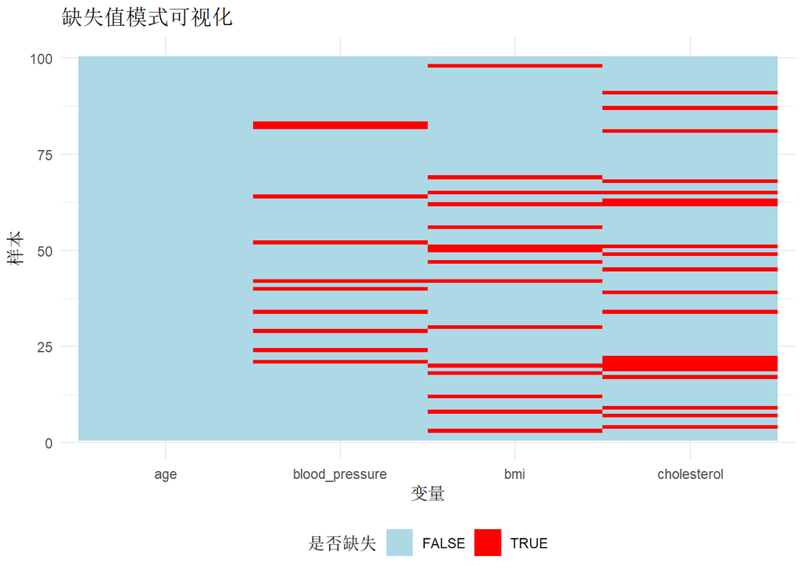

```r
# 可视化缺失模式
visdat <- data_with_na[-1]
visdat$rown <- 1:nrow(visdat)
visdat_long <- tidyr::pivot_longer(visdat, cols = -rown, names_to = "variable", values_to = "value")
visdat_long$is_na <- is.na(visdat_long$value)

ggplot2::ggplot(visdat_long, ggplot2::aes(x = variable, y = rown, fill = is_na)) +
  ggplot2::geom_tile() +
  ggplot2::scale_fill_manual(values = c("FALSE" = "lightblue", "TRUE" = "red")) +
  ggplot2::labs(
    title = "缺失值模式可视化",
    x = "变量", y = "样本", fill = "是否缺失"
  ) +
  ggplot2::theme_minimal() +
  ggplot2::theme(legend.position = "bottom")
```

### 简单填补方法

```r
# 均值填补
data_mean_imputed <- data_with_na
data_mean_imputed$bmi[is.na(data_mean_imputed$bmi)] <- mean(data_mean_imputed$bmi, na.rm = TRUE)
data_mean_imputed$blood_pressure[is.na(data_mean_imputed$blood_pressure)] <- mean(data_mean_imputed$blood_pressure, na.rm = TRUE)
data_mean_imputed$cholesterol[is.na(data_mean_imputed$cholesterol)] <- mean(data_mean_imputed$cholesterol, na.rm = TRUE)

# 中位数填补（对异常值更稳健）
data_median_imputed <- data_with_na
data_median_imputed$bmi[is.na(data_median_imputed$bmi)] <- median(data_median_imputed$bmi, na.rm = TRUE)
data_median_imputed$blood_pressure[is.na(data_median_imputed$blood_pressure)] <- median(data_median_imputed$blood_pressure, na.rm = TRUE)
data_median_imputed$cholesterol[is.na(data_median_imputed$cholesterol)] <- median(data_median_imputed$cholesterol, na.rm = TRUE)

# 使用caret包的preProcess
preproc_impute <- caret::preProcess(data_with_na[-1], method = "medianImpute")
data_caret_imputed <- predict(preproc_impute, data_with_na[-1])

# 比较填补结果
impute_compare <- data.frame(
  变量 = c("bmi", "blood_pressure", "cholesterol"),
  原始均值 = c(mean(data_with_na$bmi, na.rm = TRUE),
                mean(data_with_na$blood_pressure, na.rm = TRUE),
                mean(data_with_na$cholesterol, na.rm = TRUE)),
  均值填补后均值 = c(mean(data_mean_imputed$bmi),
                      mean(data_mean_imputed$blood_pressure),
                      mean(data_mean_imputed$cholesterol)),
  中位数填补后均值 = c(mean(data_median_imputed$bmi),
                        mean(data_median_imputed$blood_pressure),
                        mean(data_median_imputed$cholesterol))
)

print(impute_compare)
```

```
##             变量  原始均值 均值填补后均值 中位数填补后均值
## 1            bmi  24.66353       24.66353           24.669
## 2 blood_pressure 121.02222      121.02222          121.020
## 3    cholesterol 202.73750      202.73750          201.690
```

### K近邻填补（KNN Imputation）

**原理**：利用K个最相似样本的值进行填补。

```r
# KNN填补
preproc_knn <- caret::preProcess(data_with_na[-1], method = "knnImpute")
data_knn_imputed <- predict(preproc_knn, data_with_na[-1])

# 注意：KNN填补需要先标准化数据
# caret会自动处理

# 查看填补结果
head(data_knn_imputed)
```

```
##          age        bmi blood_pressure cholesterol
## 1  1.3066901  1.4338767     -2.0204150 -0.06333831
## 2 -0.5427005  1.2663831      0.2944158  0.81587837
## 3  0.2863367 -0.8440364      1.0824434 -0.01706374
## 4  0.5414250  2.1596823      1.9689744 -0.46129954
## 5  0.3501088 -0.6597935     -1.4293944 -0.22529927
## 6 -0.1600679  0.2055902     -1.1831358 -0.13275015
```

### 模型预测填补

**原理**：用其他变量作为特征，训练模型预测缺失值。

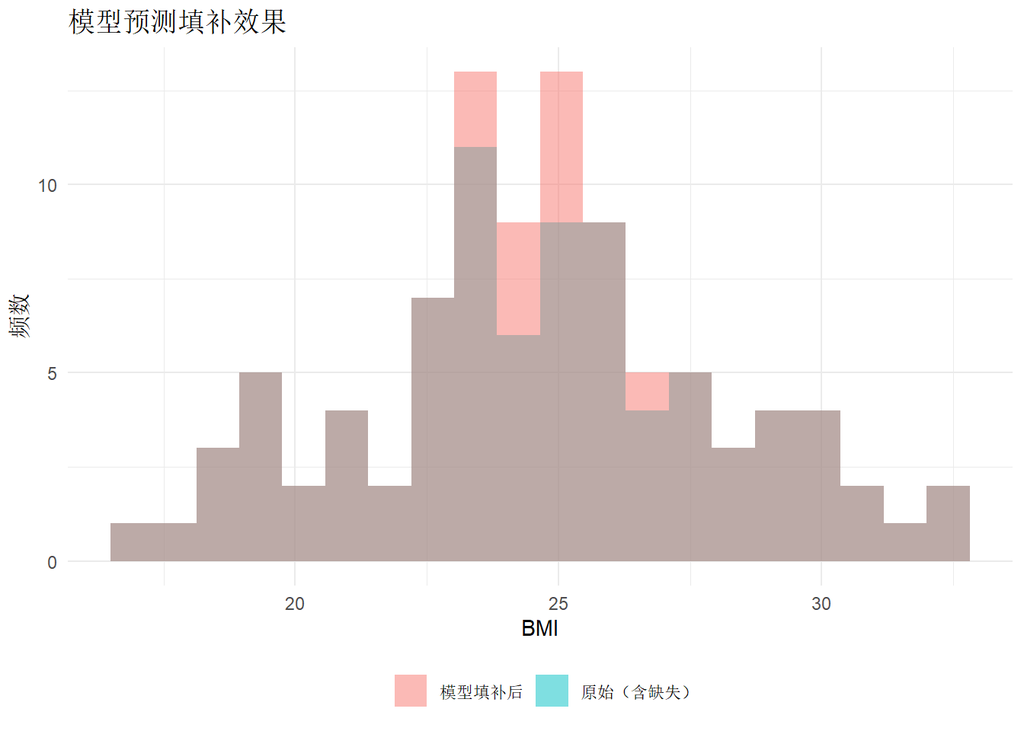

```r
# 使用mice包进行多重插补（如果可用）
# 这里演示简单的模型预测填补

# 用其他变量预测bmi的缺失值
bmi_complete <- data_with_na[!is.na(data_with_na$bmi), ]
bmi_missing <- data_with_na[is.na(data_with_na$bmi), ]

# 训练线性回归模型
bmi_model <- lm(bmi ~ age + blood_pressure + cholesterol, data = bmi_complete)

# 预测缺失值
predicted_bmi <- predict(bmi_model, newdata = bmi_missing)

# 填补
data_model_imputed <- data_with_na
data_model_imputed$bmi[is.na(data_model_imputed$bmi)] <- predicted_bmi

# 可视化填补效果
ggplot2::ggplot() +
  ggplot2::geom_histogram(ggplot2::aes(x = data_with_na$bmi, fill = "原始（含缺失）"),
                          alpha = 0.5, bins = 20, na.rm = TRUE) +
  ggplot2::geom_histogram(ggplot2::aes(x = data_model_imputed$bmi, fill = "模型填补后"),
                          alpha = 0.5, bins = 20) +
  ggplot2::labs(
    title = "模型预测填补效果",
    x = "BMI", y = "频数", fill = ""
  ) +
  ggplot2::theme_minimal() +
  ggplot2::theme(legend.position = "bottom")
```

### 缺失值处理策略选择

| 缺失比例 | 推荐方法 | 原因 |
| --- | --- | --- |
| < 5% | 简单填补/删除 | 影响小 |
| 5-20% | KNN/模型填补 | 保留更多信息 |
| > 20% | 考虑删除变量 | 信息损失严重 |

### 意义与使用场景

**核心意义**：合理的缺失值处理可以保留数据信息，避免引入偏差。

**举例**：临床试验数据分析

**场景**：一项药物临床试验，部分患者未完成所有随访检查。

**为什么不能简单删除缺失样本？**

如果删除所有有缺失值的样本，可能导致：1. 样本量大幅减少；2. 删除的样本可能有特殊性（如病情重的患者更可能失访），引入选择偏差。

**如何选择填补方法？**

如果缺失是随机的（MCAR），可以用均值填补。如果缺失与其他变量相关（MAR），应该用模型预测填补。如果缺失与自身值相关（MNAR），需要更复杂的方法如模式混合模型。

## 2.4 特征选择（过滤法、包装法、嵌入法）

### 为什么需要特征选择？

1. **降低维度**：减少计算成本
2. **提高性能**：去除噪声特征
3. **增强可解释性**：识别关键因素
4. **防止过拟合**：减少模型复杂度

### 三种特征选择方法

| 方法 | 原理 | 优点 | 缺点 |
| --- | --- | --- | --- |
| 过滤法 | 基于统计指标筛选 | 快速、独立于模型 | 忽略特征间关系 |
| 包装法 | 用模型性能评估特征组合 | 考虑特征间关系 | 计算成本高 |
| 嵌入法 | 在模型训练中自动选择 | 高效、模型特定 | 依赖特定模型 |

```r
# 使用Sonar数据集演示特征选择
data(Sonar, package = "mlbench")

# 查看数据维度
cat("数据维度：", dim(Sonar), "\n")
```

```
## 数据维度： 208 61
```

```r
cat("特征数量：", ncol(Sonar) - 1, "\n")
```

```
## 特征数量： 60
```

```r
# 划分训练集和测试集
set.seed(42)
train_index <- caret::createDataPartition(Sonar$Class, p = 0.7, list = FALSE)
train_data <- Sonar[train_index, ]
test_data <- Sonar[-train_index, ]
```

### 过滤法（Filter Methods）

**原理**：基于统计指标（如相关性、方差、信息增益）评估每个特征的重要性。

```r
# 方差阈值法：删除方差过小的特征
feature_vars <- apply(train_data[, -ncol(train_data)], 2, var)
low_var_features <- names(feature_vars[feature_vars < 0.01])

cat("低方差特征数量：", length(low_var_features), "\n")
```

```
## 低方差特征数量： 22
```

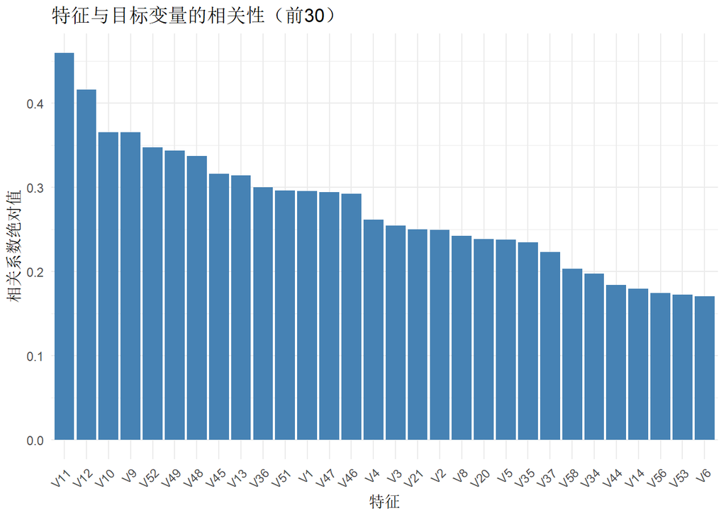

```r
# 相关性过滤：删除与目标变量相关性低的特征
# 计算每个特征与目标变量的相关性
correlations <- sapply(names(train_data)[-ncol(train_data)], function(col) {
  cor(as.numeric(train_data[[col]]), as.numeric(train_data$Class))
})

# 选择相关性最高的前20个特征
top_features <- names(sort(abs(correlations), decreasing = TRUE))[1:20]

# 可视化特征相关性
cor_df <- data.frame(
  feature = names(correlations),
  correlation = abs(correlations)
)

cor_df <- cor_df[order(cor_df$correlation, decreasing = TRUE), ]
cor_df$feature <- factor(cor_df$feature, levels = cor_df$feature)

ggplot2::ggplot(head(cor_df, 30), ggplot2::aes(x = feature, y = correlation)) +
  ggplot2::geom_bar(stat = "identity", fill = "steelblue") +
  ggplot2::labs(
    title = "特征与目标变量的相关性（前30）",
    x = "特征", y = "相关系数绝对值"
  ) +
  ggplot2::theme_minimal() +
  ggplot2::theme(axis.text.x = ggplot2::element_text(angle = 45, hjust = 1))
```

### 包装法（Wrapper Methods）

**原理**：通过训练模型评估特征子集的性能，搜索最优特征组合。

```r
# 递归特征消除（Recursive Feature Elimination, RFE）
set.seed(42)

# 定义控制参数
rfe_control <- caret::rfeControl(
  functions = caret::rfFuncs,  # 使用随机森林
  method = "cv",               # 交叉验证
  number = 5                   # 5折
)

# 执行RFE
rfe_result <- caret::rfe(
  x = train_data[, -ncol(train_data)],
  y = train_data$Class,
  sizes = c(5, 10, 20, 30, 40, 50),
  rfeControl = rfe_control
)

# 查看结果
print(rfe_result)
```

```
##
## Recursive feature selection
##
## Outer resampling method: Cross-Validated (5 fold)
##
## Resampling performance over subset size:
##
##  Variables Accuracy  Kappa AccuracySD KappaSD Selected
##          5   0.7875 0.5714    0.08620 0.17187
##         10   0.7870 0.5691    0.07636 0.15293
##         20   0.8208 0.6385    0.05967 0.12223
##         30   0.8489 0.6955    0.04050 0.08250
##         40   0.8553 0.7081    0.05310 0.10718
##         50   0.8351 0.6672    0.03162 0.06428
##         60   0.8694 0.7364    0.05197 0.10351        *
##
## The top 5 variables (out of 60):
##    V11, V12, V9, V52, V36
```

```r
# 最优特征数量
cat("\n最优特征数量：", rfe_result$bestSubset, "\n")
```

```
##
## 最优特征数量： 60
```

```r
cat("选中的特征：\n")
```

```
## 选中的特征：
```

```r
print(rfe_result$optVariables)
```

```
##  [1] "V11" "V12" "V9"  "V52" "V36" "V48" "V10" "V13" "V47" "V28" "V46" "V21"
## [13] "V49" "V27" "V37" "V51" "V20" "V16" "V17" "V18" "V2"  "V45" "V14" "V5"
## [25] "V1"  "V4"  "V34" "V23" "V8"  "V31" "V15" "V3"  "V33" "V19" "V44" "V59"
## [37] "V42" "V6"  "V43" "V24" "V26" "V25" "V54" "V35" "V53" "V39" "V30" "V32"
## [49] "V60" "V58" "V22" "V40" "V38" "V55" "V7"  "V56" "V29" "V41" "V57" "V50"
```

### 嵌入法（Embedded Methods）

**原理**：在模型训练过程中自动进行特征选择。

```r
# 使用带正则化的模型（如LASSO）
# 使用glmnet包

# 准备数据
x_train <- as.matrix(train_data[, -ncol(train_data)])
y_train <- ifelse(train_data$Class == "M", 1, 0)

# 使用caret训练LASSO模型
set.seed(42)
lasso_model <- caret::train(
  x = x_train,
  y = train_data$Class,
  method = "glmnet",
  trControl = caret::trainControl(method = "cv", number = 5),
  tuneGrid = data.frame(alpha = 1, lambda = seq(0.001, 0.1, length.out = 20))
)

# 查看模型
print(lasso_model)
```

```
## glmnet
##
## 146 samples
##  60 predictor
##   2 classes: 'M', 'R'
##
## No pre-processing
## Resampling: Cross-Validated (5 fold)
## Summary of sample sizes: 117, 118, 116, 117, 116
## Resampling results across tuning parameters:
##
##   lambda       Accuracy   Kappa
##   0.001000000  0.7386864  0.4749746
##   0.006210526  0.7796223  0.5568986
##   0.011421053  0.7660755  0.5296068
##   0.016631579  0.7724959  0.5426466
##   0.021842105  0.7582102  0.5130910
##   0.027052632  0.7786700  0.5554115
##   0.032263158  0.7786700  0.5554115
##   0.037473684  0.7791461  0.5550158
##   0.042684211  0.7860427  0.5685974
##   0.047894737  0.7998522  0.5952532
##   0.053105263  0.8003448  0.5965009
##   0.058315789  0.8005747  0.5962016
##   0.063526316  0.8008046  0.5973741
##   0.068736842  0.7939080  0.5825084
##   0.073947368  0.7867652  0.5688028
##   0.079157895  0.7870115  0.5695442
##   0.084368421  0.7870115  0.5695442
##   0.089578947  0.7732020  0.5410120
##   0.094789474  0.7798686  0.5549569
##   0.100000000  0.7658292  0.5260499
##
## Tuning parameter 'alpha' was held constant at a value of 1
## Accuracy was used to select the optimal model using the largest value.
## The final values used for the model were alpha = 1 and lambda = 0.06352632.
```

```r
# 获取非零系数的特征
lasso_coefs <- coef(lasso_model$finalModel, lasso_model$bestTune$lambda)
selected_features <- rownames(lasso_coefs)[lasso_coefs[, 1] != 0][-1]  # 排除截距

cat("\nLASSO选中的特征数量：", length(selected_features), "\n")
```

```
##
## LASSO选中的特征数量： 9
```

```r
cat("选中的特征：\n")
```

```
## 选中的特征：
```

```r
print(selected_features)
```

```
## [1] "V11" "V12" "V21" "V28" "V36" "V45" "V48" "V49" "V52"
```

### 特征选择方法对比

| 方法 | 计算速度 | 考虑特征交互 | 推荐场景 |
| --- | --- | --- | --- |
| 过滤法 | 快 | 否 | 初步筛选 |
| 包装法（RFE） | 慢 | 是 | 精度要求高 |
| 嵌入法（LASSO） | 中 | 是 | 高维数据 |

### 意义与使用场景

**核心意义**：特征选择可以提高模型性能、降低过拟合风险、增强可解释性。

**举例**：基因表达数据分析

**场景**：分析1000个基因的表达水平与疾病的关系，样本只有100例。

**为什么特征选择至关重要？**

特征数（1000）远大于样本数（100），如果不进行特征选择，模型会严重过拟合。需要筛选出与疾病真正相关的少数基因。

**如何选择方法？**

1. 先用过滤法快速筛选（如单变量检验p值）
2. 再用嵌入法精细选择（如LASSO）
3. 最后用包装法验证（如RFE）

## 2.5 特征提取（PCA、LDA）

### 特征选择 vs 特征提取

| 方法 | 原理 | 特点 |
| --- | --- | --- |
| 特征选择 | 从原始特征中选择子集 | 保留原始特征含义 |
| 特征提取 | 创建新的特征组合 | 新特征是原始特征的线性组合 |

### 主成分分析（PCA）

**原理**：找到数据方差最大的方向，将数据投影到低维空间。

**数学表达**：

寻找投影方向 $w$，使得投影后的方差最大：

$$\max_w \text{Var}(Xw) = \max_w w^T
\Sigma w$$

其中 $\Sigma$ 是协方差矩阵。

```r
# PCA示例：使用iris数据集
data(iris)

# 只取数值特征
iris_numeric <- iris[, 1:4]

# 执行PCA
pca_result <- prcomp(iris_numeric, scale. = TRUE)

# 查看主成分
print(summary(pca_result))
```

```
## Importance of components:
##                           PC1    PC2     PC3     PC4
## Standard deviation     1.7084 0.9560 0.38309 0.14393
## Proportion of Variance 0.7296 0.2285 0.03669 0.00518
## Cumulative Proportion  0.7296 0.9581 0.99482 1.00000
```

```r
# 方差解释比例
var_explained <- pca_result$sdev^2 / sum(pca_result$sdev^2)

var_df <- data.frame(
  PC = paste0("PC", 1:4),
  方差解释比例 = var_explained,
  累积解释比例 = cumsum(var_explained)
)

print(var_df)
```

```
##    PC 方差解释比例 累积解释比例
## 1 PC1  0.729624454    0.7296245
## 2 PC2  0.228507618    0.9581321
## 3 PC3  0.036689219    0.9948213
## 4 PC4  0.005178709    1.0000000
```

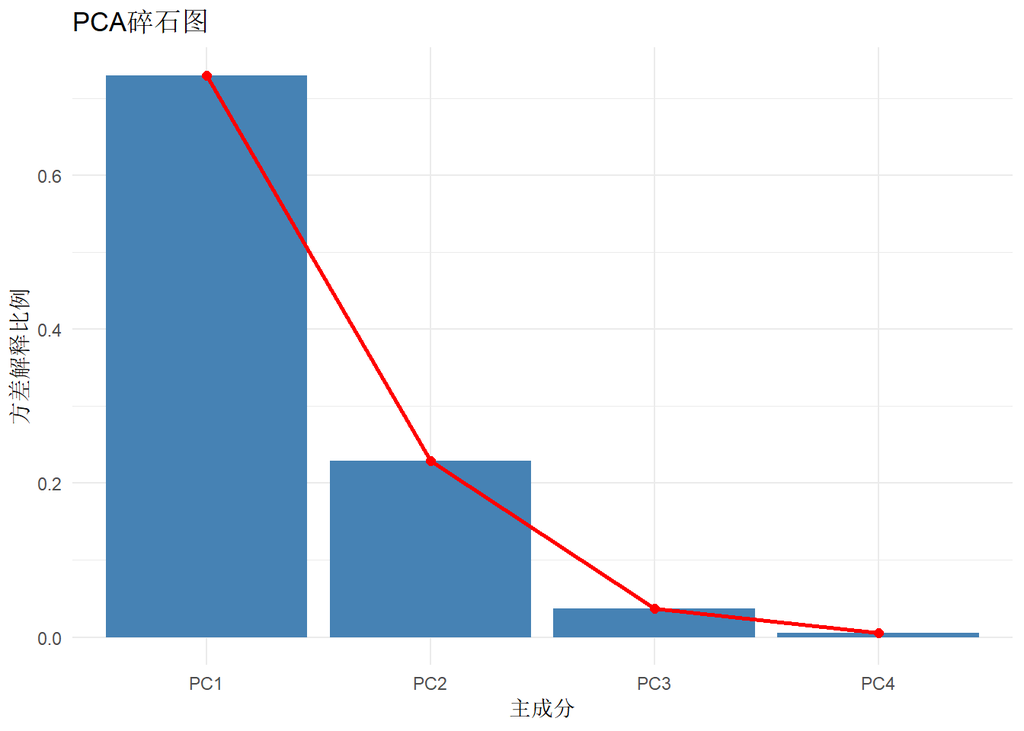

```r
# 碎石图
ggplot2::ggplot(var_df, ggplot2::aes(x = PC, y = 方差解释比例)) +
  ggplot2::geom_bar(stat = "identity", fill = "steelblue") +
  ggplot2::geom_line(ggplot2::aes(group = 1), color = "red", linewidth = 1) +
  ggplot2::geom_point(color = "red", size = 2) +
  ggplot2::labs(
    title = "PCA碎石图",
    x = "主成分", y = "方差解释比例"
  ) +
  ggplot2::theme_minimal()
```

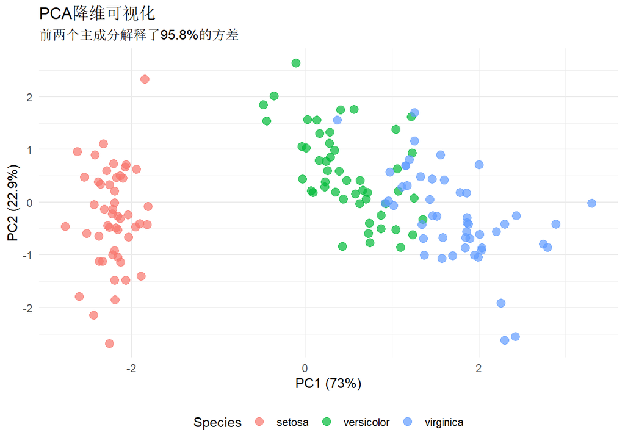

```r
# 可视化前两个主成分
pca_scores <- as.data.frame(pca_result$x)
pca_scores$Species <- iris$Species

ggplot2::ggplot(pca_scores, ggplot2::aes(x = PC1, y = PC2, color = Species)) +
  ggplot2::geom_point(size = 3, alpha = 0.7) +
  ggplot2::labs(
    title = "PCA降维可视化",
    subtitle = "前两个主成分解释了95.8%的方差",
    x = paste0("PC1 (", round(var_explained[1] * 100, 1), "%)"),
    y = paste0("PC2 (", round(var_explained[2] * 100, 1), "%)")
  ) +
  ggplot2::theme_minimal() +
  ggplot2::theme(legend.position = "bottom")
```

### 线性判别分析（LDA）

**原理**：找到能最好区分类别的投影方向，最大化类间方差、最小化类内方差。

**数学表达**：

$$\max_w \frac{w^T S_B w}{w^T S_W
w}$$

其中 $S_B$ 是类间散度矩阵，$S_W$ 是类内散度矩阵。

```r
# LDA示例
# 使用MASS包的lda函数

lda_result <- MASS::lda(Species ~ ., data = iris)

# 查看结果
print(lda_result)
```

```
## Call:
## lda(Species ~ ., data = iris)
##
## Prior probabilities of groups:
##     setosa versicolor  virginica
##  0.3333333  0.3333333  0.3333333
##
## Group means:
##            Sepal.Length Sepal.Width Petal.Length Petal.Width
## setosa            5.006       3.428        1.462       0.246
## versicolor        5.936       2.770        4.260       1.326
## virginica         6.588       2.974        5.552       2.026
##
## Coefficients of linear discriminants:
##                     LD1         LD2
## Sepal.Length  0.8293776 -0.02410215
## Sepal.Width   1.5344731 -2.16452123
## Petal.Length -2.2012117  0.93192121
## Petal.Width  -2.8104603 -2.83918785
##
## Proportion of trace:
##    LD1    LD2
## 0.9912 0.0088
```

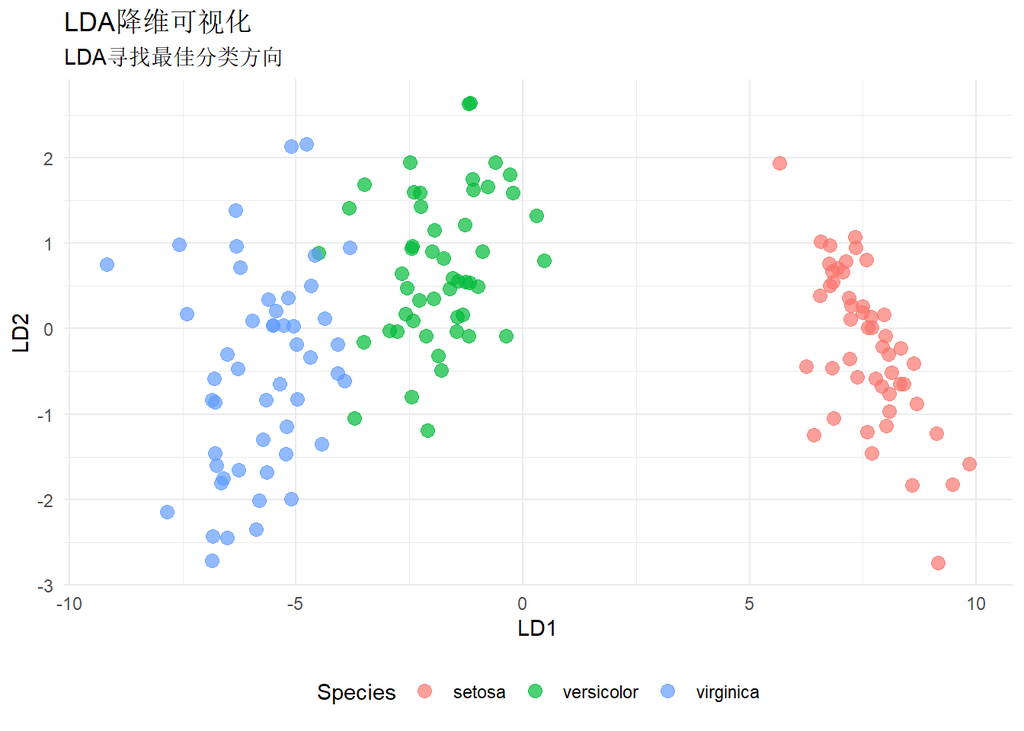

```r
# 预测并可视化
lda_pred <- predict(lda_result, iris)
lda_scores <- as.data.frame(lda_pred$x)
lda_scores$Species <- iris$Species

ggplot2::ggplot(lda_scores, ggplot2::aes(x = LD1, y = LD2, color = Species)) +
  ggplot2::geom_point(size = 3, alpha = 0.7) +
  ggplot2::labs(
    title = "LDA降维可视化",
    subtitle = "LDA寻找最佳分类方向",
    x = "LD1", y = "LD2"
  ) +
  ggplot2::theme_minimal() +
  ggplot2::theme(legend.position = "bottom")
```

### PCA vs LDA 对比

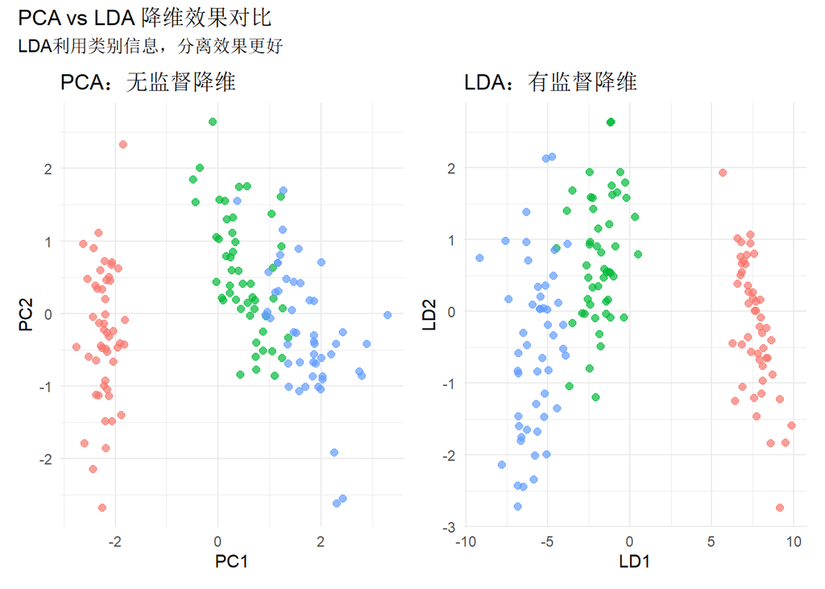

```r
# 对比PCA和LDA的降维效果
p1 <- ggplot2::ggplot(pca_scores, ggplot2::aes(x = PC1, y = PC2, color = Species)) +
  ggplot2::geom_point(size = 2, alpha = 0.7) +
  ggplot2::labs(title = "PCA：无监督降维", x = "PC1", y = "PC2") +
  ggplot2::theme_minimal() +
  ggplot2::theme(legend.position = "none")

p2 <- ggplot2::ggplot(lda_scores, ggplot2::aes(x = LD1, y = LD2, color = Species)) +
  ggplot2::geom_point(size = 2, alpha = 0.7) +
  ggplot2::labs(title = "LDA：有监督降维", x = "LD1", y = "LD2") +
  ggplot2::theme_minimal() +
  ggplot2::theme(legend.position = "none")

p1 + p2 + patchwork::plot_annotation(
  title = "PCA vs LDA 降维效果对比",
  subtitle = "LDA利用类别信息，分离效果更好"
)
```

### 意义与使用场景

**核心意义**：特征提取可以在保留信息的同时降低维度，便于可视化和建模。

**举例**：基因表达数据分析

**场景**：分析10000个基因的表达谱，需要降维后进行可视化或建模。

**选择PCA还是LDA？**

如果目的是数据探索、可视化，选择PCA（无监督）。如果目的是分类，选择LDA（有监督，利用类别信息）。但LDA最多只能提取K-1个成分（K是类别数），对于二分类问题只有1个成分。

## 2.6 特征交互与多项式特征

### 为什么需要特征交互？

有时特征之间存在交互效应，单个特征的影响取决于另一个特征的值。

**医学示例**：药物A的疗效可能取决于患者是否同时服用药物B。

```r
# 创建模拟数据演示特征交互
set.seed(42)
n <- 200

interaction_data <- data.frame(
  age = round(runif(n, 30, 80)),
  bmi = round(rnorm(n, 25, 4), 1),
  smoking = sample(c(0, 1), n, replace = TRUE),
  exercise = sample(c(0, 1), n, replace = TRUE)
)

# 生成目标变量（包含交互效应）
# 吸烟对风险的影响随年龄增加而增强
interaction_data$risk_score <-
  0.5 * interaction_data$age +
  2 * interaction_data$bmi +
  20 * interaction_data$smoking +
  0.3 * interaction_data$age * interaction_data$smoking +  # 交互效应
  rnorm(n, 0, 5)

# 查看数据
head(interaction_data)
```

```
##   age  bmi smoking exercise risk_score
## 1  76 29.8       1        1  145.54570
## 2  77 29.2       1        1  144.57387
## 3  44 21.0       1        1   97.18772
## 4  72 32.4       1        0  143.08005
## 5  62 22.3       1        1  110.59923
## 6  56 25.4       0        1   77.80938
```

### 创建交互特征

```r
# 手动创建交互特征
interaction_data$age_smoking <- interaction_data$age * interaction_data$smoking
interaction_data$bmi_exercise <- interaction_data$bmi * interaction_data$exercise

# 使用模型验证交互效应的重要性
model_no_interaction <- lm(risk_score ~ age + bmi + smoking + exercise,
                           data = interaction_data)
model_with_interaction <- lm(risk_score ~ age + bmi + smoking + exercise +
                               age:smoking + bmi:exercise,
                             data = interaction_data)

# 比较模型
anova_result <- anova(model_no_interaction, model_with_interaction)
print(anova_result)
```

```
## Analysis of Variance Table
##
## Model 1: risk_score ~ age + bmi + smoking + exercise
## Model 2: risk_score ~ age + bmi + smoking + exercise + age:smoking + bmi:exercise
##   Res.Df    RSS Df Sum of Sq      F    Pr(>F)
## 1    195 5809.0
## 2    193 4988.8  2    820.14 15.864 4.181e-07 ***
## ---
## Signif. codes:  0 '***' 0.001 '**' 0.01 '*' 0.05 '.' 0.1 ' ' 1
```

```r
# 查看交互项系数
summary(model_with_interaction)
```

```
##
## Call:
## lm(formula = risk_score ~ age + bmi + smoking + exercise + age:smoking +
##     bmi:exercise, data = interaction_data)
##
## Residuals:
##      Min       1Q   Median       3Q      Max
## -12.3919  -3.5348  -0.0625   3.7397  17.4802
##
## Coefficients:
##              Estimate Std. Error t value Pr(>|t|)
## (Intercept)  -2.48097    3.80750  -0.652    0.515
## age           0.54573    0.03428  15.919  < 2e-16 ***
## bmi           1.98366    0.13167  15.065  < 2e-16 ***
## smoking      22.58550    2.88465   7.830 3.17e-13 ***
## exercise      5.33206    4.77227   1.117    0.265
## age:smoking   0.26817    0.04969   5.397 1.97e-07 ***
## bmi:exercise -0.23562    0.18994  -1.240    0.216
## ---
## Signif. codes:  0 '***' 0.001 '**' 0.01 '*' 0.05 '.' 0.1 ' ' 1
##
## Residual standard error: 5.084 on 193 degrees of freedom
## Multiple R-squared:  0.9562, Adjusted R-squared:  0.9548
## F-statistic: 702.1 on 6 and 193 DF,  p-value: < 2.2e-16
```

### 多项式特征

**原理**：添加特征的幂次项，捕捉非线性关系。

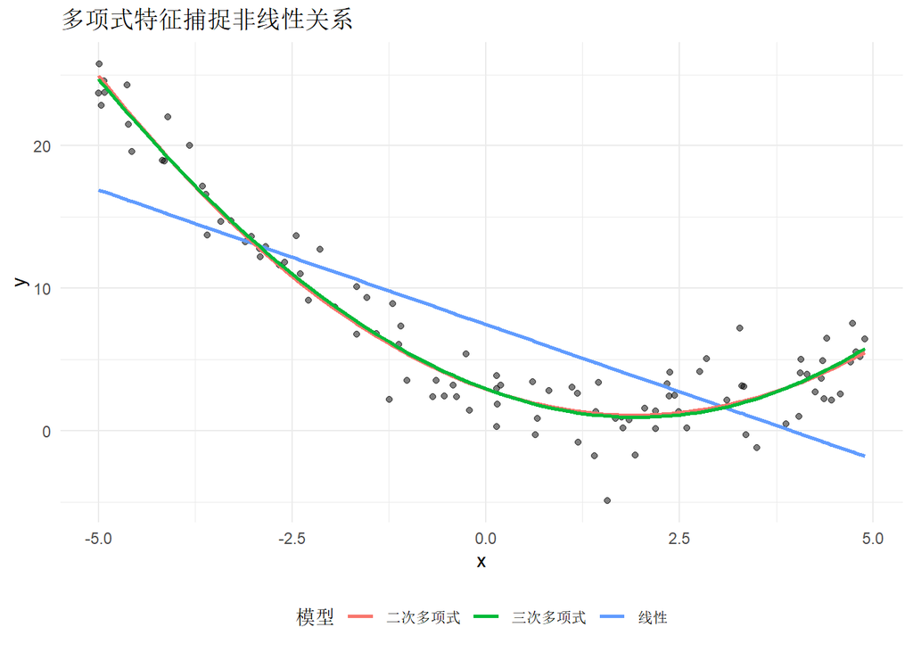

```r
# 多项式特征示例
set.seed(42)
n <- 100

# 生成非线性关系数据
poly_data <- data.frame(
  x = runif(n, -5, 5)
)
poly_data$y <- 0.5 * poly_data$x^2 - 2 * poly_data$x + 3 + rnorm(n, 0, 2)

# 线性模型
model_linear <- lm(y ~ x, data = poly_data)

# 多项式模型（二次）
model_poly2 <- lm(y ~ poly(x, degree = 2, raw = TRUE), data = poly_data)

# 多项式模型（三次）
model_poly3 <- lm(y ~ poly(x, degree = 3, raw = TRUE), data = poly_data)

# 预测
poly_data$pred_linear <- predict(model_linear)
poly_data$pred_poly2 <- predict(model_poly2)
poly_data$pred_poly3 <- predict(model_poly3)

# 可视化
ggplot2::ggplot(poly_data, ggplot2::aes(x = x, y = y)) +
  ggplot2::geom_point(alpha = 0.5) +
  ggplot2::geom_line(ggplot2::aes(y = pred_linear, color = "线性"), linewidth = 1) +
  ggplot2::geom_line(ggplot2::aes(y = pred_poly2, color = "二次多项式"), linewidth = 1) +
  ggplot2::geom_line(ggplot2::aes(y = pred_poly3, color = "三次多项式"), linewidth = 1) +
  ggplot2::labs(
    title = "多项式特征捕捉非线性关系",
    x = "x", y = "y", color = "模型"
  ) +
  ggplot2::theme_minimal() +
  ggplot2::theme(legend.position = "bottom")
```

### 意义与使用场景

**核心意义**：特征交互和多项式特征可以捕捉复杂的非线性关系。

**举例**：药物相互作用研究

**场景**：研究两种药物联合使用的效果。

**为什么需要交互特征？**

药物A单独使用可能效果一般，药物B单独使用也效果一般，但两者联合使用时效果显著增强（协同效应）。这种交互效应需要通过交互特征来捕捉。

**需要注意什么？**

添加过多交互特征和多项式特征会导致：1. 维度爆炸；2. 过拟合风险增加。应该基于领域知识选择有意义的交互特征，或使用正则化方法控制复杂度。

## 2.7 处理不平衡数据（过采样、欠采样、SMOTE）

### 类别不平衡问题

在医学数据中，类别不平衡非常常见，如罕见疾病的诊断。

**问题**：模型可能倾向于预测多数类，导致少数类的预测性能很差。

```r
# 创建不平衡数据集
set.seed(42)
n <- 1000

imbalanced_data <- data.frame(
  feature1 = c(rnorm(100, mean = 2, sd = 1), rnorm(900, mean = 0, sd = 1)),
  feature2 = c(rnorm(100, mean = 2, sd = 1), rnorm(900, mean = 0, sd = 1)),
  class = factor(c(rep("Positive", 100), rep("Negative", 900)))
)

# 查看类别分布
table(imbalanced_data$class)
```

```
##
## Negative Positive
##      900      100
```

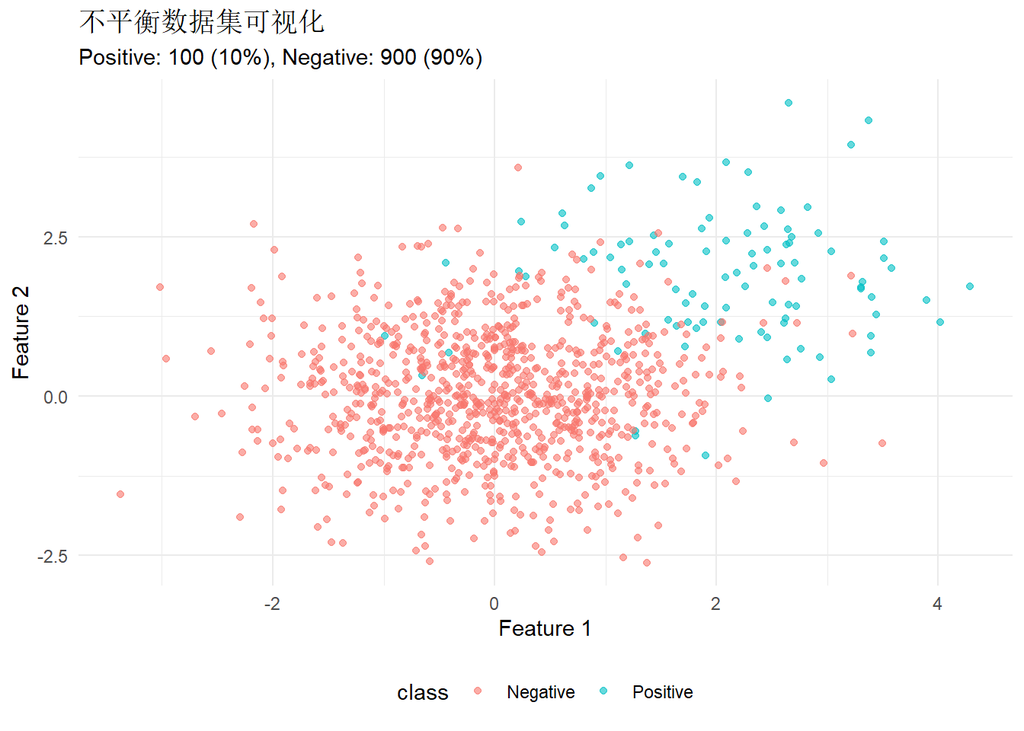

```r
# 可视化
ggplot2::ggplot(imbalanced_data, ggplot2::aes(x = feature1, y = feature2, color = class)) +
  ggplot2::geom_point(size = 1.5, alpha = 0.6) +
  ggplot2::labs(
    title = "不平衡数据集可视化",
    subtitle = "Positive: 100 (10%), Negative: 900 (90%)",
    x = "Feature 1", y = "Feature 2"
  ) +
  ggplot2::theme_minimal() +
  ggplot2::theme(legend.position = "bottom")
```

### 过采样（Oversampling）

**原理**：增加少数类样本，使两类数量接近。

```r
# 过采样：复制少数类样本
positive_samples <- imbalanced_data[imbalanced_data$class == "Positive", ]
negative_samples <- imbalanced_data[imbalanced_data$class == "Negative", ]

# 简单复制过采样
oversampled <- rbind(
  positive_samples[sample(1:nrow(positive_samples), 800, replace = TRUE), ],
  negative_samples
)

# 查看平衡后的分布
table(oversampled$class)
```

```
##
## Negative Positive
##      900      800
```

### 欠采样（Undersampling）

**原理**：减少多数类样本，使两类数量接近。

```r
# 欠采样：随机抽取多数类样本
undersampled <- rbind(
  positive_samples,
  negative_samples[sample(1:nrow(negative_samples), 100), ]
)

# 查看平衡后的分布
table(undersampled$class)
```

```
##
## Negative Positive
##      100      100
```

### SMOTE（Synthetic Minority Over-sampling Technique）

**原理**：在少数类样本之间插值生成新样本。

```r
# SMOTE原理示意
set.seed(42)

# 选择两个少数类样本
sample1 <- as.numeric(positive_samples[1, 1:2])
sample2 <- as.numeric(positive_samples[2, 1:2])

# 在两点之间随机插值生成新样本
alpha <- runif(1)
new_sample <- sample1 + alpha * (sample2 - sample1)

cat("原始样本1：", sample1, "\n")
```

```
## 原始样本1： 3.370958 4.325058
```

```r
cat("原始样本2：", sample2, "\n")
```

```
## 原始样本2： 1.435302 2.524122
```

```r
cat("生成的新样本：", new_sample, "\n")
```

```
## 生成的新样本： 1.600208 2.677551
```

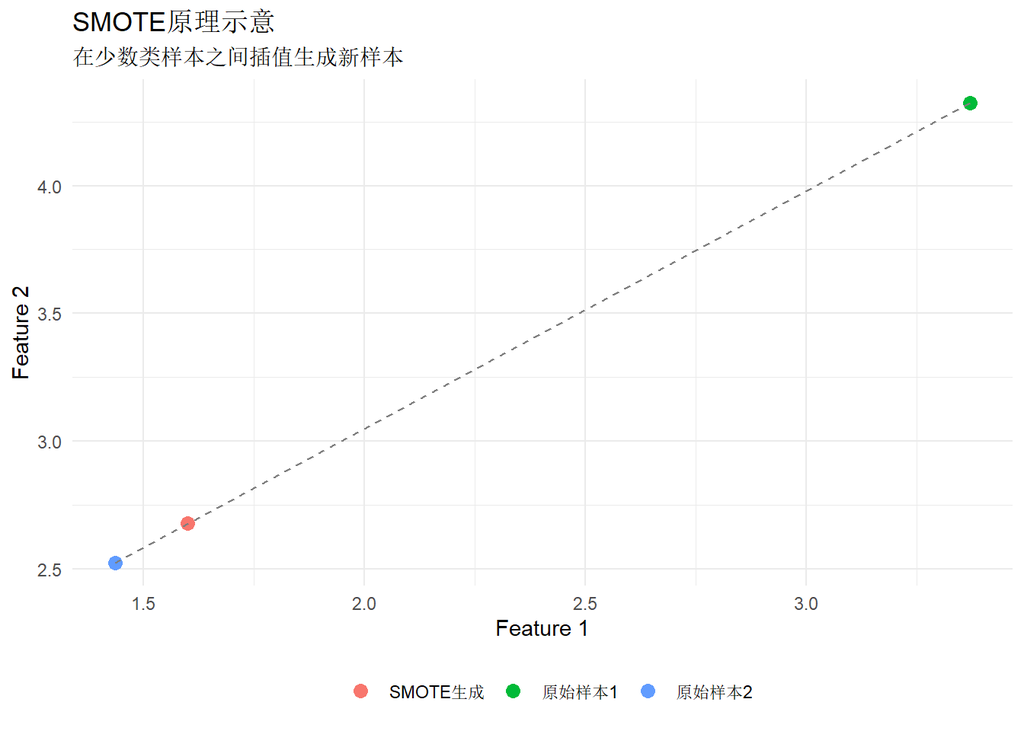

```r
# 可视化SMOTE
smote_viz <- data.frame(
  x = c(sample1[1], sample2[1], new_sample[1]),
  y = c(sample1[2], sample2[2], new_sample[2]),
  type = c("原始样本1", "原始样本2", "SMOTE生成")
)

ggplot2::ggplot(smote_viz, ggplot2::aes(x = x, y = y, color = type)) +
  ggplot2::geom_point(size = 3) +
  ggplot2::geom_line(data = data.frame(x = c(sample1[1], sample2[1]),
                                        y = c(sample1[2], sample2[2])),
                     ggplot2::aes(x = x, y = y), color = "gray50", linetype = "dashed") +
  ggplot2::labs(
    title = "SMOTE原理示意",
    subtitle = "在少数类样本之间插值生成新样本",
    x = "Feature 1", y = "Feature 2", color = ""
  ) +
  ggplot2::theme_minimal() +
  ggplot2::theme(legend.position = "bottom")
```

### 不同方法的对比

| 方法 | 优点 | 缺点 | 适用场景 |
| --- | --- | --- | --- |
| 过采样 | 不丢失信息 | 容易过拟合 | 数据量小 |
| 欠采样 | 计算效率高 | 丢失信息 | 数据量大 |
| SMOTE | 生成新样本 | 可能生成噪声 | 常用选择 |

### 意义与使用场景

**核心意义**：处理类别不平衡可以提高模型对少数类的识别能力。

**举例**：罕见疾病诊断

**场景**：某种罕见疾病的发病率只有1%，需要开发诊断模型。

**为什么需要处理不平衡？**

如果不处理，模型可能学会”总是预测健康”，准确率高达99%，但完全无法识别患者。处理不平衡后，模型会更关注少数类（患者），提高召回率。

**如何选择方法？**

数据量小（<1000）：过采样或SMOTE。数据量大（>10000）：欠采样。也可以结合使用：先欠采样多数类，再用SMOTE生成少数类。

## 2.8 时间特征工程（滞后、滚动统计）

### 时间序列特征

对于时间序列数据，需要创建能够捕捉时间依赖性的特征。

```r
# 创建模拟时间序列数据
set.seed(42)
n_days <- 365

time_data <- data.frame(
  date = seq(as.Date("2023-01-01"), by = "day", length.out = n_days),
  patients = round(100 + 20 * sin(2 * pi * 1:n_days / 365) +  # 年周期
                   5 * sin(2 * pi * 1:n_days / 7) +            # 周周期
                   rnorm(n_days, 0, 10))                       # 随机波动
)

# 查看数据
head(time_data)
```

```
##         date patients
## 1 2023-01-01      118
## 2 2023-01-02      100
## 3 2023-01-03      107
## 4 2023-01-04      106
## 5 2023-01-05      101
## 6 2023-01-06       97
```

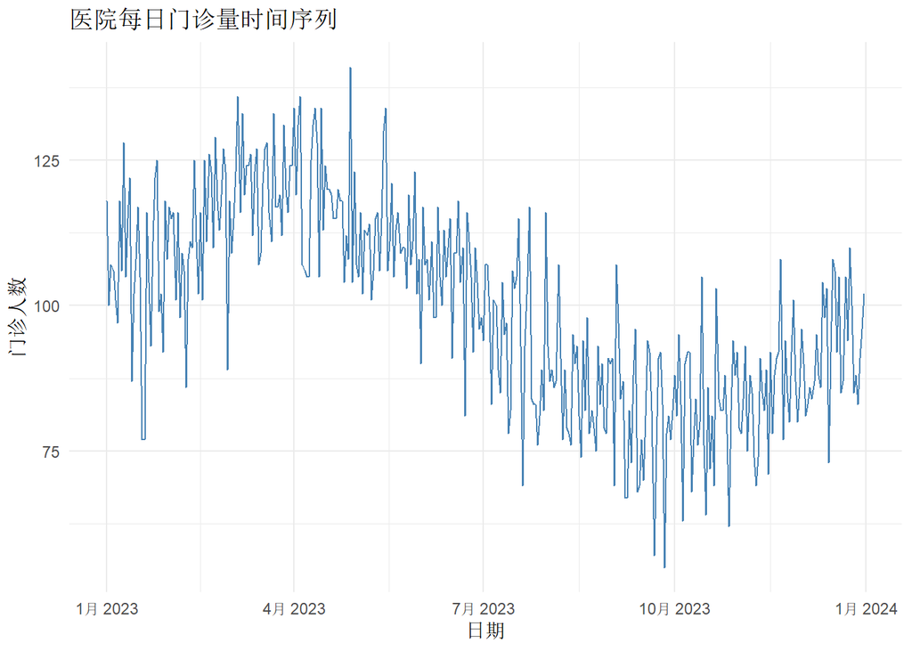

```r
# 可视化
ggplot2::ggplot(time_data, ggplot2::aes(x = date, y = patients)) +
  ggplot2::geom_line(color = "steelblue") +
  ggplot2::labs(
    title = "医院每日门诊量时间序列",
    x = "日期", y = "门诊人数"
  ) +
  ggplot2::theme_minimal()
```

### 滞后特征（Lag Features）

**原理**：使用过去时间点的值作为当前时间点的特征。

```r
# 创建滞后特征
time_data <- time_data %>%
  dplyr::mutate(
    lag_1 = dplyr::lag(patients, 1),   # 前1天
    lag_7 = dplyr::lag(patients, 7),   # 前7天（上周同一天）
    lag_30 = dplyr::lag(patients, 30)  # 前30天
  )

# 查看滞后特征
head(time_data[30:35, ], 10)
```

```
##          date patients lag_1 lag_7 lag_30
## 30 2023-01-30      108   118   111     NA
## 31 2023-01-31      117   108   122    118
## 32 2023-02-01      115   117   125    100
## 33 2023-02-02      116   115    99    107
## 34 2023-02-03      101   116   102    106
## 35 2023-02-04      116   101    92    101
```

### 滚动统计特征

**原理**：计算过去一段时间窗口内的统计量。

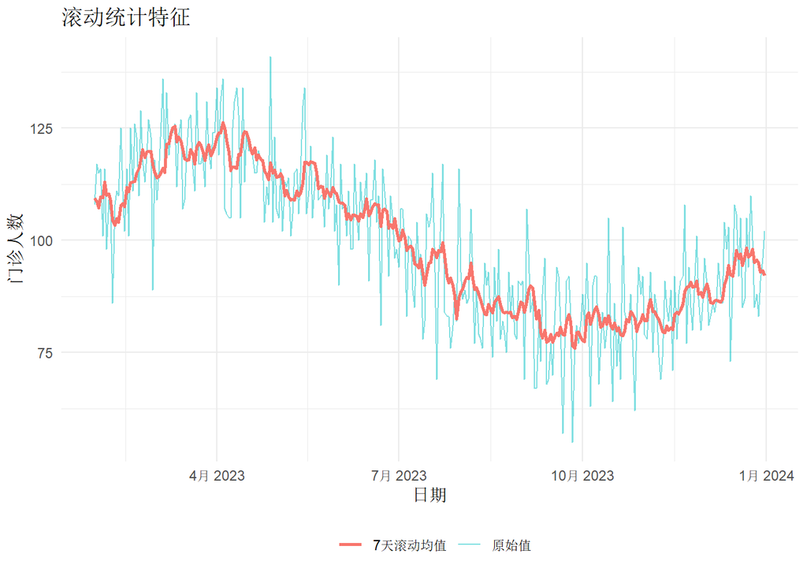

```r
# 创建滚动统计特征
time_data <- time_data %>%
  dplyr::mutate(
    # 7天滚动均值
    rolling_mean_7 = zoo::rollmean(patients, k = 7, fill = NA, align = "right"),
    # 7天滚动标准差
    rolling_sd_7 = zoo::rollapply(patients, width = 7, FUN = sd, fill = NA, align = "right"),
    # 7天滚动最大值
    rolling_max_7 = zoo::rollapply(patients, width = 7, FUN = max, fill = NA, align = "right")
  )

# 可视化滚动统计
ggplot2::ggplot(time_data[30:n_days, ], ggplot2::aes(x = date)) +
  ggplot2::geom_line(ggplot2::aes(y = patients, color = "原始值"), alpha = 0.5) +
  ggplot2::geom_line(ggplot2::aes(y = rolling_mean_7, color = "7天滚动均值"), linewidth = 1) +
  ggplot2::labs(
    title = "滚动统计特征",
    x = "日期", y = "门诊人数", color = ""
  ) +
  ggplot2::theme_minimal() +
  ggplot2::theme(legend.position = "bottom")
```

### 时间分解特征

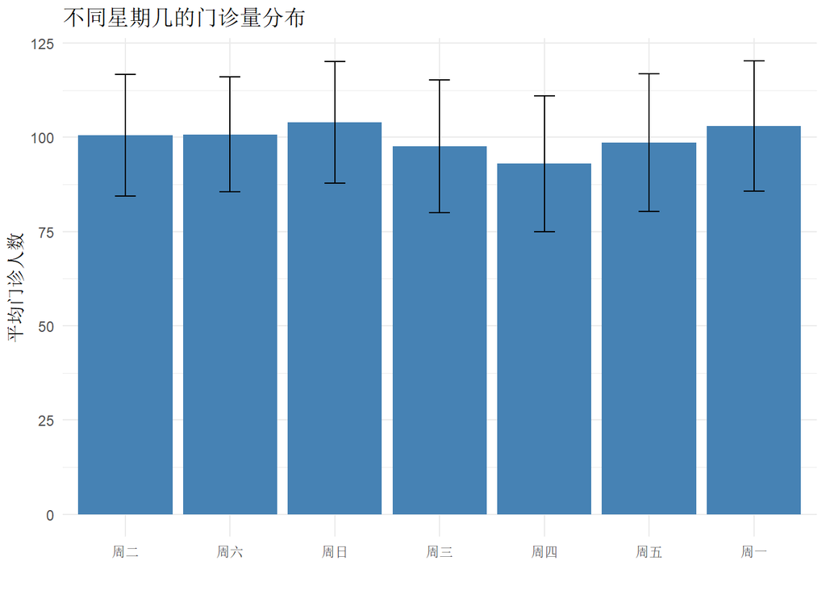

```r
# 提取时间分解特征
time_data <- time_data %>%
  dplyr::mutate(
    year = as.numeric(format(date, "%Y")),
    month = as.numeric(format(date, "%m")),
    day = as.numeric(format(date, "%d")),
    weekday = as.numeric(format(date, "%w")),  # 0-6, 周日为0
    is_weekend = weekday %in% c(0, 6)
  )

# 按星期几统计
weekday_stats <- time_data %>%
  dplyr::group_by(weekday) %>%
  dplyr::summarise(
    mean_patients = mean(patients),
    sd_patients = sd(patients),
    .groups = "drop"
  )

weekday_stats$weekday_name <- c("周日", "周一", "周二", "周三", "周四", "周五", "周六")

ggplot2::ggplot(weekday_stats, ggplot2::aes(x = weekday_name, y = mean_patients)) +
  ggplot2::geom_bar(stat = "identity", fill = "steelblue") +
  ggplot2::geom_errorbar(ggplot2::aes(ymin = mean_patients - sd_patients,
                                       ymax = mean_patients + sd_patients),
                         width = 0.2) +
  ggplot2::labs(
    title = "不同星期几的门诊量分布",
    x = "", y = "平均门诊人数"
  ) +
  ggplot2::theme_minimal()
```

### 意义与使用场景

**核心意义**：时间特征工程可以捕捉时间序列数据中的模式和依赖性。

**举例**：预测医院每日门诊量

**场景**：医院需要预测未来一周的每日门诊量，以便合理安排医护人员。

**如何构建特征？**

1. 滞后特征：前一天的门诊量、上周同一天的门诊量
2. 滚动统计：过去7天的平均门诊量
3. 时间分解：星期几、是否节假日、月份
4. 趋势特征：门诊量的变化趋势